# Práctica 1 - Casas by Javier Ramos

```python
import pandas as pd
import numpy as np
import seaborn as sns
import matplotlib.pyplot as plt
%matplotlib inline
sns.set(color_codes=True)
```

**Ejercicio Nº1**

En primer lugar utilizaremos la función read_excel de la librería pandas para leer el DS, que está relacionada con información sobre una serie de inmuebles.

```python
x = pd.read_excel("/DatosAED.xlsx")
x.head(5)
```

|  | Order | MS Zoning | Lot Frontage | Lot Area | Land Contour | Land Slope | Overall Qual | Year Built | Year Remod/Add | Mas Vnr Type | ... | Kitchen Qual | TotRms AbvGrd | Garage Cars | Garage Area | Garage Cond | Pool Area | Pool QC | Mo Sold | Yr Sold | SalePrice |
| --- | --- | --- | --- | --- | --- | --- | --- | --- | --- | --- | --- | --- | --- | --- | --- | --- | --- | --- | --- | --- | --- |
| 0 | 1 | RL | 141.0 | 31770 | Lvl | Gtl | 6 | 1960 | 1960 | Stone | ... | TA | 7 | 2.0 | 528.0 | TA | 0 | Sp | 5 | 2010 | 215000 |
| 1 | 2 | RH | 80.0 | 11622 | Lvl | Gtl | 5 | 1961 | 1961 | None | ... | TA | 5 | 1.0 | 730.0 | TA | 0 | Sp | 6 | 2010 | 105000 |
| 2 | 3 | RL | 81.0 | 14267 | Lvl | Gtl | 6 | 1958 | 1958 | BrkFace | ... | Gd | 6 | 1.0 | 312.0 | TA | 0 | Sp | 6 | 2010 | 172000 |
| 3 | 4 | RL | 93.0 | 11160 | Lvl | Gtl | 7 | 1968 | 1968 | None | ... | Ex | 8 | 2.0 | 522.0 | TA | 0 | Sp | 4 | 2010 | 244000 |
| 4 | 5 | RL | 74.0 | 13830 | Lvl | Gtl | 5 | 1997 | 1998 | None | ... | TA | 6 | 2.0 | 482.0 | TA | 0 | Sp | 3 | 2010 | 189900 |

5 rows × 29 columns

Ahora eliminaremos los espacios existentes entre los nombres de las columnas, de esta manera será más fácil operar con ellos.

Utilizando el str.replace cambiamos los espacios por barras baja, y en la siguiente línea pondremos todos las letras en minúscula.

```python
x.columns = x.columns.str.replace(' ','_')
x.columns = map(str.lower,x.columns)
x.head(5)
```

|  | order | ms_zoning | lot_frontage | lot_area | land_contour | land_slope | overall_qual | year_built | year_remod/add | mas_vnr_type | ... | kitchen_qual | totrms_abvgrd | garage_cars | garage_area | garage_cond | pool_area | pool_qc | mo_sold | yr_sold | saleprice |
| --- | --- | --- | --- | --- | --- | --- | --- | --- | --- | --- | --- | --- | --- | --- | --- | --- | --- | --- | --- | --- | --- |
| 0 | 1 | RL | 141.0 | 31770 | Lvl | Gtl | 6 | 1960 | 1960 | Stone | ... | TA | 7 | 2.0 | 528.0 | TA | 0 | Sp | 5 | 2010 | 215000 |
| 1 | 2 | RH | 80.0 | 11622 | Lvl | Gtl | 5 | 1961 | 1961 | None | ... | TA | 5 | 1.0 | 730.0 | TA | 0 | Sp | 6 | 2010 | 105000 |
| 2 | 3 | RL | 81.0 | 14267 | Lvl | Gtl | 6 | 1958 | 1958 | BrkFace | ... | Gd | 6 | 1.0 | 312.0 | TA | 0 | Sp | 6 | 2010 | 172000 |
| 3 | 4 | RL | 93.0 | 11160 | Lvl | Gtl | 7 | 1968 | 1968 | None | ... | Ex | 8 | 2.0 | 522.0 | TA | 0 | Sp | 4 | 2010 | 244000 |
| 4 | 5 | RL | 74.0 | 13830 | Lvl | Gtl | 5 | 1997 | 1998 | None | ... | TA | 6 | 2.0 | 482.0 | TA | 0 | Sp | 3 | 2010 | 189900 |

5 rows × 29 columns

Utilizando la función info de la librería pandas nobtendremos información valiosa como: nombres de columnas, los valores no nulos, y el tipo de datos que alberga cada columna.

```python
x.info()
```

```
<class 'pandas.core.frame.DataFrame'>
RangeIndex: 2930 entries, 0 to 2929
Data columns (total 29 columns):
 #   Column          Non-Null Count  Dtype
---  ------          --------------  -----
 0   order           2930 non-null   int64
 1   ms_zoning       2930 non-null   object
 2   lot_frontage    2440 non-null   float64
 3   lot_area        2930 non-null   int64
 4   land_contour    2930 non-null   object
 5   land_slope      2930 non-null   object
 6   overall_qual    2930 non-null   int64
 7   year_built      2930 non-null   int64
 8   year_remod/add  2930 non-null   int64
 9   mas_vnr_type    2907 non-null   object
```

[output cut: 21 more lines]

Crearemos la variable DATE, la que juntaremos los datos del mes en el que se vendió 'mo_sold' y el año en el que se vendió 'yr_sold' eliminando del DS ambas columnas que ya no serán relevantes.

```python
from datetime import datetime
x['date']= (x.apply(lambda x: datetime(x.yr_sold,x.mo_sold,15),axis=1))
x = x.drop(['mo_sold','yr_sold'], axis = 1)
x.head(5)
```

|  | order | ms_zoning | lot_frontage | lot_area | land_contour | land_slope | overall_qual | year_built | year_remod/add | mas_vnr_type | ... | kitchen_abvgr | kitchen_qual | totrms_abvgrd | garage_cars | garage_area | garage_cond | pool_area | pool_qc | saleprice | date |
| --- | --- | --- | --- | --- | --- | --- | --- | --- | --- | --- | --- | --- | --- | --- | --- | --- | --- | --- | --- | --- | --- |
| 0 | 1 | RL | 141.0 | 31770 | Lvl | Gtl | 6 | 1960 | 1960 | Stone | ... | 1 | TA | 7 | 2.0 | 528.0 | TA | 0 | Sp | 215000 | 2010-05-15 |
| 1 | 2 | RH | 80.0 | 11622 | Lvl | Gtl | 5 | 1961 | 1961 | None | ... | 1 | TA | 5 | 1.0 | 730.0 | TA | 0 | Sp | 105000 | 2010-06-15 |
| 2 | 3 | RL | 81.0 | 14267 | Lvl | Gtl | 6 | 1958 | 1958 | BrkFace | ... | 1 | Gd | 6 | 1.0 | 312.0 | TA | 0 | Sp | 172000 | 2010-06-15 |
| 3 | 4 | RL | 93.0 | 11160 | Lvl | Gtl | 7 | 1968 | 1968 | None | ... | 1 | Ex | 8 | 2.0 | 522.0 | TA | 0 | Sp | 244000 | 2010-04-15 |
| 4 | 5 | RL | 74.0 | 13830 | Lvl | Gtl | 5 | 1997 | 1998 | None | ... | 1 | TA | 6 | 2.0 | 482.0 | TA | 0 | Sp | 189900 | 2010-03-15 |

5 rows × 28 columns

Para observar el número total de valores missing, utilizaremos la función .isna y después le aplicaremos un sum() para que nos enseñe el número total de NA's por variable.

```python
x.isna().sum()
```

```
order               0
ms_zoning           0
lot_frontage      490
lot_area            0
land_contour        0
land_slope          0
overall_qual        0
year_built          0
year_remod/add      0
mas_vnr_type       23
exter_qual          0
bsmt_cond           0
total_bsmt_sf       0
heating_qc          0
central_air         0
full_bath           0
half_bath           0
bedroom_abvgr       0
kitchen_abvgr       0
kitchen_qual        0
totrms_abvgrd       0
garage_cars         1
garage_area         1
garage_cond         2
pool_area           0
pool_qc             0
saleprice           0
date                0
dtype: int64
```

Rellenaremos todos aquellos huecos en los que hay valores faltantes por 0's, podría hacerse un .dropna(), sin embargo el DS no tiene una gran cantidad de datos y estaríamos eliminando información que podría ser muy levante, en concreto el 17.65% de las filas.

```python
x.fillna(0, inplace = True)
x.head()
```

|  | order | ms_zoning | lot_frontage | lot_area | land_contour | land_slope | overall_qual | year_built | year_remod/add | mas_vnr_type | ... | kitchen_abvgr | kitchen_qual | totrms_abvgrd | garage_cars | garage_area | garage_cond | pool_area | pool_qc | saleprice | date |
| --- | --- | --- | --- | --- | --- | --- | --- | --- | --- | --- | --- | --- | --- | --- | --- | --- | --- | --- | --- | --- | --- |
| 0 | 1 | RL | 141.0 | 31770 | Lvl | Gtl | 6 | 1960 | 1960 | Stone | ... | 1 | TA | 7 | 2.0 | 528.0 | TA | 0 | Sp | 215000 | 2010-05-15 |
| 1 | 2 | RH | 80.0 | 11622 | Lvl | Gtl | 5 | 1961 | 1961 | None | ... | 1 | TA | 5 | 1.0 | 730.0 | TA | 0 | Sp | 105000 | 2010-06-15 |
| 2 | 3 | RL | 81.0 | 14267 | Lvl | Gtl | 6 | 1958 | 1958 | BrkFace | ... | 1 | Gd | 6 | 1.0 | 312.0 | TA | 0 | Sp | 172000 | 2010-06-15 |
| 3 | 4 | RL | 93.0 | 11160 | Lvl | Gtl | 7 | 1968 | 1968 | None | ... | 1 | Ex | 8 | 2.0 | 522.0 | TA | 0 | Sp | 244000 | 2010-04-15 |
| 4 | 5 | RL | 74.0 | 13830 | Lvl | Gtl | 5 | 1997 | 1998 | None | ... | 1 | TA | 6 | 2.0 | 482.0 | TA | 0 | Sp | 189900 | 2010-03-15 |

5 rows × 28 columns

**Ejercicio Nº2**

A continuación, seleccionaremos todos los datos pertenecientes a los años 2009 y 2010, accediendo a ellos a traves de la función .dt.year de la variable date que habíamos creado previamente. También ordenaremos los datos por antigüedad, de más antiguo a más reciente.

```python
y = x[(x['date'].dt.year == 2009) | (x['date'].dt.year == 2010)]
y = y.sort_values(["date"])
y.head(5)
```

|  | order | ms_zoning | lot_frontage | lot_area | land_contour | land_slope | overall_qual | year_built | year_remod/add | mas_vnr_type | ... | kitchen_abvgr | kitchen_qual | totrms_abvgrd | garage_cars | garage_area | garage_cond | pool_area | pool_qc | saleprice | date |
| --- | --- | --- | --- | --- | --- | --- | --- | --- | --- | --- | --- | --- | --- | --- | --- | --- | --- | --- | --- | --- | --- |
| 536 | 537 | RL | 96.0 | 10628 | Lvl | Gtl | 7 | 2004 | 2004 | None | ... | 1 | Gd | 8 | 2.0 | 478.0 | TA | 0 | Sp | 193000 | 2009-01-15 |
| 577 | 578 | RL | 80.0 | 9600 | Low | Mod | 8 | 1976 | 1976 | BrkFace | ... | 1 | TA | 5 | 2.0 | 527.0 | TA | 0 | Sp | 180500 | 2009-01-15 |
| 742 | 743 | RM | 51.0 | 6120 | Lvl | Gtl | 2 | 1936 | 1950 | None | ... | 1 | Fa | 4 | 0.0 | 0.0 | Sg | 0 | Sp | 60000 | 2009-01-15 |
| 755 | 756 | RM | 52.0 | 6240 | Lvl | Gtl | 4 | 1925 | 1950 | None | ... | 1 | TA | 5 | 2.0 | 539.0 | TA | 0 | Sp | 103000 | 2009-01-15 |
| 955 | 956 | RL | 0.0 | 14375 | Lvl | Gtl | 6 | 1958 | 1958 | BrkFace | ... | 1 | Gd | 7 | 2.0 | 525.0 | TA | 0 | Sp | 137500 | 2009-01-15 |

5 rows × 28 columns

Para estudiar la relación de la variable precio con resto de las variables, realizaremos la matriz de correlaciones y la graficaremos a partir de un mapa de calor con estilo white, para mejorar su apariencia, un tamaño de figura que nos permita ver bien los números de su interior, y un título.

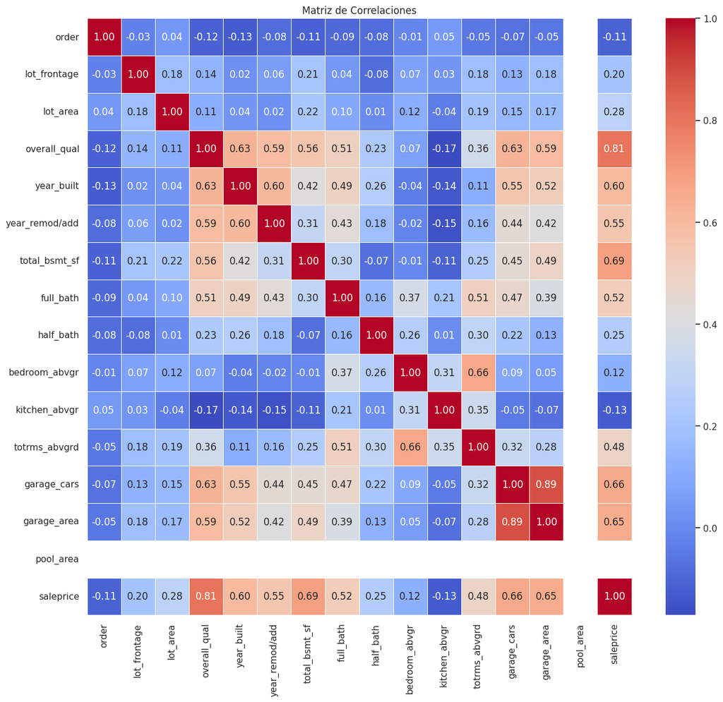

```python
mcorr = y.corr()

sns.set(style="white")
plt.figure(figsize=(15, 15))
sns.heatmap(mcorr, annot=True, cmap='coolwarm', fmt='.2f', linewidths=0.5)
plt.subplots_adjust(bottom=0.2)
plt.title('Matriz de Correlaciones')
plt.show()
```

En este mapa de calor podemos observar en primer lugar que las correlaciones más bajas están en azul y a medida que esta correlación aumenta se van poniendo más rojas.

Para mirar la relación de la variable precio con el resto podemos fijarnos tanto en la última fila, como en la última columna.

En cuanto a la relación, podemos ver como la variable pool_area no nos da ningún tipo de información. Las 3 variables menos relevantes a la hora de dictaminar el precio de venta en los años 2009 y 2010 son: order (nº de observación), kitchen_abvgr (cocinas sobre rasante) y bedroom_abvgr (habitaciones sobre rasante).

En cambio las 3 variables que más influyen sobre el precio de venta son: overall_qual (calidad ), total_bsmt_sf (superficie) y garage_cars (cantidad de coches que caben en el garaje).

**Ejercicio Nº3**

En primer lugar, creamos los intervalos de precio, que serán bajo, medio y alto. Después, creamos la variable price_range en el DS de 2009 y 2010, dividiendo a la variable saleprice en 3 intervalos. Tras esto ordenamos la variable saleprice de menor a mayor.

```python
iv = ['Bajo','Medio','Alto']
y_seg = y
y_seg['price_range'] = pd.qcut(x = y['saleprice'], q = 3, labels = iv )
y_seg = y_seg.sort_values(["saleprice"])
y_seg.head(5)
```

|  | order | ms_zoning | lot_frontage | lot_area | land_contour | land_slope | overall_qual | year_built | year_remod/add | mas_vnr_type | ... | kitchen_qual | totrms_abvgrd | garage_cars | garage_area | garage_cond | pool_area | pool_qc | saleprice | date | price_range |
| --- | --- | --- | --- | --- | --- | --- | --- | --- | --- | --- | --- | --- | --- | --- | --- | --- | --- | --- | --- | --- | --- |
| 181 | 182 | RM | 68.0 | 9656 | Lvl | Gtl | 2 | 1923 | 1970 | None | ... | TA | 5 | 2.0 | 780.0 | Fa | 0 | Sp | 12789 | 2010-06-15 | Bajo |
| 726 | 727 | C | 60.0 | 7879 | Lvl | Gtl | 4 | 1920 | 1950 | None | ... | TA | 4 | 0.0 | 0.0 | Sg | 0 | Sp | 34900 | 2009-11-15 | Bajo |
| 709 | 710 | RM | 50.0 | 5925 | Lvl | Gtl | 3 | 1910 | 1950 | None | ... | TA | 6 | 0.0 | 0.0 | Sg | 0 | Sp | 37900 | 2009-05-15 | Bajo |
| 727 | 728 | C | 72.0 | 9392 | Lvl | Gtl | 3 | 1900 | 1950 | None | ... | TA | 5 | 0.0 | 0.0 | Sg | 0 | Sp | 44000 | 2009-09-15 | Bajo |
| 708 | 709 | RM | 50.0 | 5925 | Lvl | Gtl | 2 | 1940 | 1950 | None | ... | TA | 4 | 1.0 | 308.0 | Fa | 0 | Sp | 45000 | 2009-10-15 | Bajo |

5 rows × 29 columns

Ahora reprentaremos esta nueva variable con cada una de las 3 variables más relevantes a la hora de dictaminar el precio, y lo haremos mediante box plots.

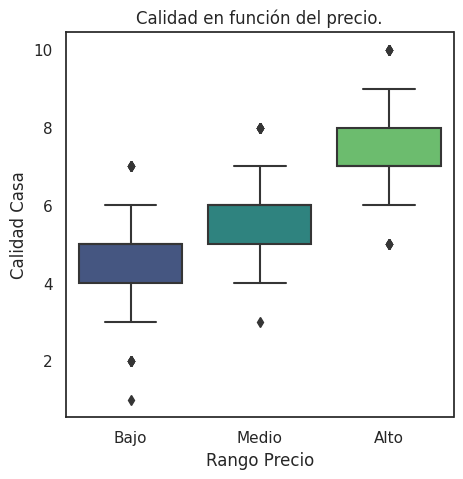

```python
plt.figure(figsize=(5, 5))
sns.boxplot(x='price_range', y='overall_qual', data=y_seg, palette = 'viridis')
plt.xlabel('Rango Precio')
plt.ylabel('Calidad Casa')
plt.title('Calidad en función del precio.')
plt.show()
```

Se puede observar que en este primer boxplot, a medida que aumenta el rango de precio, la calidad de la casa aumenta. Sin embargo, el crecimiento podemos ver que no es lineal, si no un poco exponencial. Todos los intervalos presentan outliers por encima y por debajo, pero el intervalo de precio bajo, tiene más outliers que el resto.

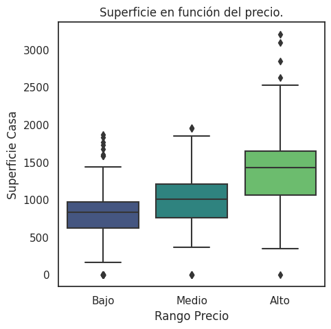

```python
plt.figure(figsize=(5, 5))
sns.boxplot(x='price_range', y='total_bsmt_sf', data=y_seg, palette = 'viridis')
plt.xlabel('Rango Precio')
plt.ylabel('Superficie Casa')
plt.title('Superficie en función del precio.')
# plt.show()
```

En este segundo boxplot, a medida que aumenta el rango de precio, la superficie de la casa aumenta. El crecimiento es más lineal que en el anterior, sin embargo todavía sigue siendo exponencial. Los intervalos presentan más outliers por encima que en el boxplot anterior y tanto el primer como el tercer intervalo de precios bajo y alto respectivamente, tienen más outliers, siendo el precio bajo el que más presenta.

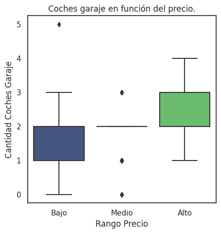

```python
plt.figure(figsize=(5, 5))
sns.boxplot(x='price_range', y='garage_cars', data=y_seg, palette = 'viridis')
plt.xlabel('Rango Precio')
plt.ylabel('Cantidad Coches Garaje')
plt.title('Coches garaje en función del precio.')
# plt.show()
```

En este último boxplot, a medida que aumenta el rango de precio, los coches que caben en el garaje aumentan. El crecimiento es lineal, en las casas de precio bajo caben entre 1 y 2 coches, en las de precio medio caben 2 y en las de precio alto entre 2 y 3. Los intervalos presentan menos outliers que en los boxplot anteriores. Hay una casa de precio bajo en la que caben 5 coches, lo cual llama bastante la atención y hay casas de precio medio que o bien, no tienen garaje o caben 1 o 3 coches.

**Ejercicio Nº4**

**En este ejercicio hay que comparar el precio de las viviendas con 3 cocinas, piscina y con 3 o más plazas de garaje que las que tienen 1 cocina, no tienen piscina y 2 plazas de garaje.**

```python
f1 = y[(y['kitchen_abvgr'] == 3) & (y['garage_cars'] >= 3)]
f1
```

|  | order | ms_zoning | lot_frontage | lot_area | land_contour | land_slope | overall_qual | year_built | year_remod/add | mas_vnr_type | ... | kitchen_qual | totrms_abvgrd | garage_cars | garage_area | garage_cond | pool_area | pool_qc | saleprice | date | price_range |
| --- | --- | --- | --- | --- | --- | --- | --- | --- | --- | --- | --- | --- | --- | --- | --- | --- | --- | --- | --- | --- | --- |

0 rows × 29 columns

Sin embargo, no hay ninguna casa del DS de los años 2009 y 2010 que cumpliese las características de 3 cocinas y que cabiesen 3 o más coches en el garaje.

```python
f2 = y[(y['kitchen_abvgr'] == 2) & (y['garage_cars'] >= 2)]
f2.head(5)
```

|  | order | ms_zoning | lot_frontage | lot_area | land_contour | land_slope | overall_qual | year_built | year_remod/add | mas_vnr_type | ... | kitchen_qual | totrms_abvgrd | garage_cars | garage_area | garage_cond | pool_area | pool_qc | saleprice | date | price_range |
| --- | --- | --- | --- | --- | --- | --- | --- | --- | --- | --- | --- | --- | --- | --- | --- | --- | --- | --- | --- | --- | --- |
| 622 | 623 | RL | 65.0 | 8944 | Lvl | Gtl | 5 | 1967 | 1967 | None | ... | TA | 8 | 3.0 | 792.0 | TA | 0 | Sp | 124000 | 2009-04-15 | Bajo |
| 551 | 552 | RL | 75.0 | 8250 | Lvl | Gtl | 6 | 1981 | 1981 | None | ... | TA | 8 | 2.0 | 612.0 | TA | 0 | Sp | 160000 | 2009-05-15 | Medio |
| 810 | 811 | RL | 64.0 | 7018 | Bnk | Gtl | 5 | 1979 | 1979 | None | ... | TA | 8 | 2.0 | 400.0 | TA | 0 | Sp | 118858 | 2009-06-15 | Bajo |
| 807 | 808 | RL | 64.0 | 7018 | Bnk | Gtl | 5 | 1979 | 1979 | None | ... | TA | 8 | 2.0 | 410.0 | TA | 0 | Sp | 118964 | 2009-06-15 | Bajo |
| 808 | 809 | RL | 64.0 | 7018 | Bnk | Gtl | 5 | 1979 | 1979 | Stone | ... | TA | 6 | 2.0 | 528.0 | TA | 0 | Sp | 153337 | 2009-06-15 | Medio |

5 rows × 29 columns

```python
f3 = y[(y['kitchen_abvgr'] ==1) & (y['garage_cars']>=1)]
f3.head(5)
```

|  | order | ms_zoning | lot_frontage | lot_area | land_contour | land_slope | overall_qual | year_built | year_remod/add | mas_vnr_type | ... | kitchen_qual | totrms_abvgrd | garage_cars | garage_area | garage_cond | pool_area | pool_qc | saleprice | date | price_range |
| --- | --- | --- | --- | --- | --- | --- | --- | --- | --- | --- | --- | --- | --- | --- | --- | --- | --- | --- | --- | --- | --- |
| 536 | 537 | RL | 96.0 | 10628 | Lvl | Gtl | 7 | 2004 | 2004 | None | ... | Gd | 8 | 2.0 | 478.0 | TA | 0 | Sp | 193000 | 2009-01-15 | Alto |
| 577 | 578 | RL | 80.0 | 9600 | Low | Mod | 8 | 1976 | 1976 | BrkFace | ... | TA | 5 | 2.0 | 527.0 | TA | 0 | Sp | 180500 | 2009-01-15 | Medio |
| 755 | 756 | RM | 52.0 | 6240 | Lvl | Gtl | 4 | 1925 | 1950 | None | ... | TA | 5 | 2.0 | 539.0 | TA | 0 | Sp | 103000 | 2009-01-15 | Bajo |
| 955 | 956 | RL | 0.0 | 14375 | Lvl | Gtl | 6 | 1958 | 1958 | BrkFace | ... | Gd | 7 | 2.0 | 525.0 | TA | 0 | Sp | 137500 | 2009-01-15 | Bajo |
| 907 | 908 | RL | 60.0 | 8400 | Bnk | Gtl | 2 | 1920 | 1950 | None | ... | Fa | 3 | 1.0 | 246.0 | TA | 0 | Sp | 60000 | 2009-01-15 | Bajo |

5 rows × 29 columns

A continuación, analizaremos los resultados de ambos grupos de viviendas construidos a través de los filtros.

```python
f2.saleprice.describe()
```

```
count        34.000000
mean     149826.470588
std       48817.542418
min       90000.000000
25%      118858.000000
50%      137500.000000
75%      159750.000000
max      269500.000000
Name: saleprice, dtype: float64
```

```python
f3.saleprice.describe()
```

```
count       898.000000
mean     184320.291759
std       79041.206528
min       12789.000000
25%      133000.000000
50%      165250.000000
75%      215800.000000
max      611657.000000
Name: saleprice, dtype: float64
```

El rango de precio es mucho mayor en el segundo grupo de viviendas que en el primero.

Hay muchos más casos en el grupo 2 que en el grupo 1. Y puede que la localización de la casa tenga un factor determinante, ya que por ejemplo una casa en el pleno centro de Madrid con 1 cocina y plaza de garaje, cueste mucho más que una casa que está muy a las afueras en un pueblo, pero tenga dos cocinas y más plazas de garaje.

Ahora graficaremos ambos grupos de casas en histogramas, para ver la distribución del número de casas a lo largo del precio de estas.

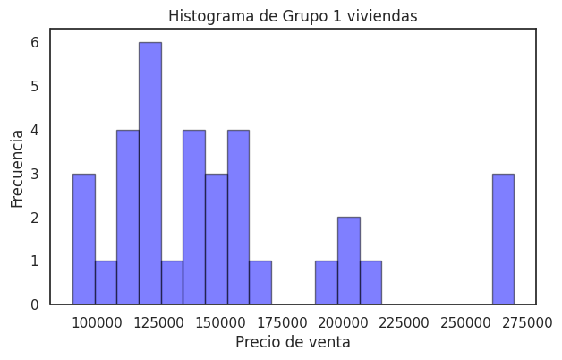

```python
plt.figure(figsize=(7, 4))
plt.hist(f2.saleprice, bins=20, color='blue', alpha= 0.5, edgecolor='black')
plt.xlabel('Precio de venta')
plt.ylabel('Frecuencia')
plt.title(f'Histograma de Grupo 1 viviendas')
plt.show()
```

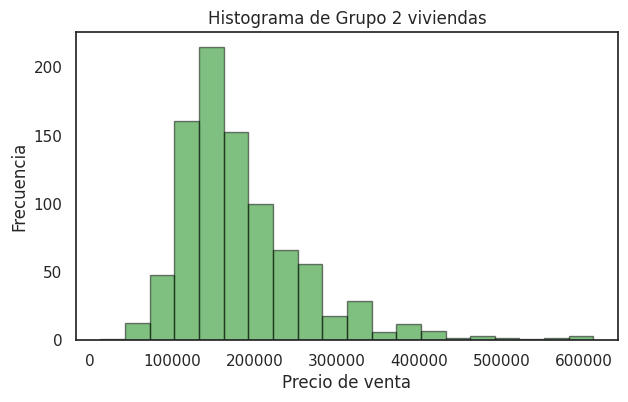

```python
plt.figure(figsize=(7, 4))
plt.hist(f3.saleprice, bins=20, color='green', alpha= 0.5, edgecolor='black')
plt.xlabel('Precio de venta')
plt.ylabel('Frecuencia')
plt.title(f'Histograma de Grupo 2 viviendas')
plt.show()
```

Podemos observar como en el segundo histrograma, el 'eje Y', tiene como máximo 200 viviendas, mientras que en el primer histograma, el máximo es 6.

También se ve que la distribución de las casas en el primer histograma está muy repartida, mientras que en el segundo histograma, además de seguir una distribución normal, están la mayoría agrupadadas entorno a 150k, solo que debido a que la cola derecha es más grande, hace que el precio medio de este grupo de viviendas crezca hasta los 184k, como veíamos en el describe anteriormente realizado.

**Ejercicio Nº5**

En este ejercicio, hay que describir las principales características de las viviendas que tienen fachada de piedra frente a las que tienen fachada de ladrillo visto, para ello aplicaremos un filtro para que sean de ladrillo en el grupo 1 y de piedra en el grupo 2, seguido de un groupby para analizar según diferentes variables relevantes.

A pesar de que también se podría aplicar un groupby directamente, sobre la variable 'mas_vnr_type', pero nos enseñaría también los demás tipos de fachada.

```python
ladrillo = x[(x['mas_vnr_type'] == 'BrkFace')]
ladrillo.groupby('mas_vnr_type').agg({'saleprice':[np.mean], 'year_built':[np.mean], 'overall_qual':[np.mean]})
```

| mas_vnr_type | saleprice mean | year_built mean | overall_qual mean |
| --- | --- | --- | --- |
| BrkFace | 210798.592045 | 1984.257955 | 6.639773 |

```python
piedra = x[(x['mas_vnr_type'] == 'Stone')]
piedra.groupby('mas_vnr_type').agg({'saleprice':[np.mean], 'year_built':[np.mean], 'overall_qual':[np.mean]})
```

| mas_vnr_type | saleprice mean | year_built mean | overall_qual mean |
| --- | --- | --- | --- |
| Stone | 260547.297189 | 1996.11245 | 7.441767 |

Como se puede observar, en cuanto al precio de venta de ambos grupos de viviendas, son 50k más caras de media, las que presentan una fachada de piedra que las de ladrillo, lo que tiene sentido ya que la piedra es una capa extra añadida al propio ladrillo y visualmente es más bonito.

También, el año de construcción de las casas con una fachada de piedra, es de 12 años de media más reciente, en comparación con las de ladrillo.

Y, por último, en la escala de calidad general de las viviendas, las casa de piedra tienen una calidad de 7.44, lo cual es 0.8 puntos de calidad por encima de aquellas que tienen una fachada de ladrillo.

**Ejercicio Nº6**

En este ejercicio hay que comprobar si se aprecia el efecto de la crisis financiera en las ventas, tanto en número como en precio. Para ello se realizara un groupby según la fecha, incluyendo la variable 'saleprice'. Y después otro, realizando un count en la variable order para ver el número de casas vendidas.

```python
p_crisis = x.groupby('date').agg({'saleprice':[np.mean]})
p_crisis.head(5)
```

| date | saleprice mean |
| --- | --- |
| 2006-01-15 | 202997.444444 |
| 2006-02-15 | 188865.208333 |
| 2006-03-15 | 182009.078431 |
| 2006-04-15 | 158864.500000 |
| 2006-05-15 | 169166.200000 |

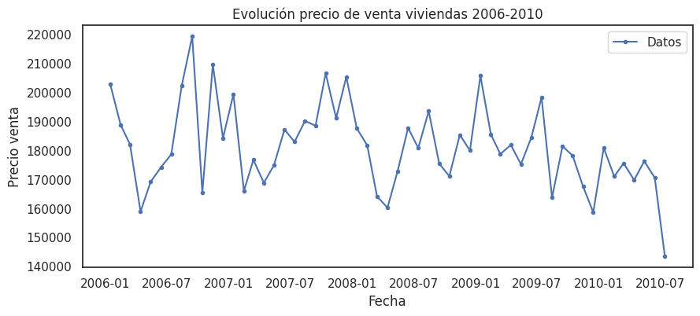

```python
plt.figure(figsize=(10, 4))
plt.plot(p_crisis['saleprice'], label='Datos', marker='.', linestyle='-')
plt.xlabel('Fecha')
plt.ylabel('Precio venta')
plt.title('Evolución precio de venta viviendas 2006-2010')
plt.legend()
plt.show()
```

Sin embargo, en Enero de 2008 aproximadamente, nos encontramos con una gran bajada hasta mayo de dicho año, coincidiendo con la crisis, cayendo el precio medio de venta en gran medida.

Tras esta fuerte caída podemos observar como poco a poco se fue recuperando, hasta alcanzar dos máximos relativos en Enero de 2009 y Julio de 2009.

```python
c_crisis = x.groupby('date').agg(numero_casas=('order', 'count'))
c_crisis.head(5)
```

| date | numero_casas |
| --- | --- |
| 2006-01-15 | 18 |
| 2006-02-15 | 24 |
| 2006-03-15 | 51 |
| 2006-04-15 | 48 |
| 2006-05-15 | 75 |

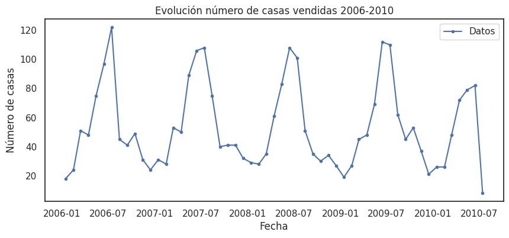

```python
plt.figure(figsize=(10, 4))
plt.plot(c_crisis['numero_casas'], label='Datos', marker='.', linestyle='-')
plt.xlabel('Fecha')
plt.ylabel('Número de casas')
plt.title('Evolución número de casas vendidas 2006-2010')
plt.legend()
plt.show()
```

En este gráfico podemos observar como el número de casas vendidas a lo largo de los años presenta estacionalidad, siendo siempre la época de Julio en la que más número de casas vendidas hay, alrededor de 100.

Tras esta fuerte caída podemos observar como en Julio de 2009, se alcanza el segundo máximo absoluto. Más tarde, vendría la misma caída que todos los años, con la diferencia de que en Junio de 2010, se vendieron alrededor de 80 casas y en vez de subir a 100 como el resto de los años, el número de casas vendidas se desplomó.